# Pareto Plots

Bruce Hartman

University of St. Francis

2026-03-01

Abstract

We demonstrate Pareto Plots from the `qcc` package and then test our own functions for them based on `ggplot`.

# Pareto Plots

Pareto plots are a good way to understand what’s important in data with categories.

# Packages

```r
library(mbadtools)
lib_packages(mbad_standard_packages)
```

```
Loading MBAD packages:
 tidyverse ggfortify GGally skimr broom gt patchwork car yardstick ggResidpanel ggh4x
```

```r
library(lmtest)
library(qcc) # for some pareto plot tools
```

# Data

Package `qcc` has several datasets with examples of Pareto Plots using their functions.

```r
data(mtcars, package="qcc") # from qcc package
mtcars
```

|  | mpg | cyl | disp | hp | drat | wt | qsec | vs | am | gear | carb |
| --- | --- | --- | --- | --- | --- | --- | --- | --- | --- | --- | --- |
| Mazda RX4 | 21.0 | 6 | 160.0 | 110 | 3.90 | 2.620 | 16.46 | 0 | 1 | 4 | 4 |
| Mazda RX4 Wag | 21.0 | 6 | 160.0 | 110 | 3.90 | 2.875 | 17.02 | 0 | 1 | 4 | 4 |
| Datsun 710 | 22.8 | 4 | 108.0 | 93 | 3.85 | 2.320 | 18.61 | 1 | 1 | 4 | 1 |
| Hornet 4 Drive | 21.4 | 6 | 258.0 | 110 | 3.08 | 3.215 | 19.44 | 1 | 0 | 3 | 1 |
| Hornet Sportabout | 18.7 | 8 | 360.0 | 175 | 3.15 | 3.440 | 17.02 | 0 | 0 | 3 | 2 |
| Valiant | 18.1 | 6 | 225.0 | 105 | 2.76 | 3.460 | 20.22 | 1 | 0 | 3 | 1 |
| Duster 360 | 14.3 | 8 | 360.0 | 245 | 3.21 | 3.570 | 15.84 | 0 | 0 | 3 | 4 |
| Merc 240D | 24.4 | 4 | 146.7 | 62 | 3.69 | 3.190 | 20.00 | 1 | 0 | 4 | 2 |
| Merc 230 | 22.8 | 4 | 140.8 | 95 | 3.92 | 3.150 | 22.90 | 1 | 0 | 4 | 2 |
| Merc 280 | 19.2 | 6 | 167.6 | 123 | 3.92 | 3.440 | 18.30 | 1 | 0 | 4 | 4 |

[output cut: 22 more lines]

```
Pareto chart analysis for cyl_count
    Frequency Cum.Freq. Percentage Cum.Percent.
  8    14.000    14.000     43.750       43.750
  4    11.000    25.000     34.375       78.125
  6     7.000    32.000     21.875      100.000
```

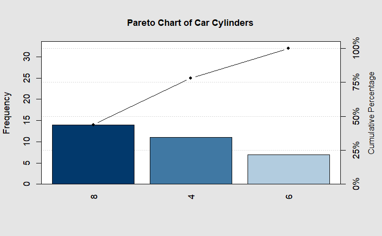

```r
cyl_count <- table(mtcars$cyl)
pareto.chart(cyl_count, main = "Pareto Chart of Car Cylinders")
```

`HairEycolor` is stored as a table.

```r
data(HairEyeColor, package="qcc")
HairEyeColor %>% str()
```

```
 'table' num [1:4, 1:4, 1:2] 32 53 10 3 11 50 10 30 10 25 ...
 - attr(*, "dimnames")=List of 3
  ..$ Hair: chr [1:4] "Black" "Brown" "Red" "Blond"
  ..$ Eye : chr [1:4] "Brown" "Blue" "Hazel" "Green"
  ..$ Sex : chr [1:2] "Male" "Female"
```

```r
HairEyeColor
```

```
, , Sex = Male

       Eye
Hair    Brown Blue Hazel Green
  Black    32   11    10     3
  Brown    53   50    25    15
  Red      10   10     7     7
  Blond     3   30     5     8

, , Sex = Female

       Eye
Hair    Brown Blue Hazel Green
  Black    36    9     5     2
  Brown    66   34    29    14
  Red      16    7     7     7
  Blond     4   64     5     8
```

```
Pareto chart analysis for eye_count
        Frequency Cum.Freq. Percentage Cum.Percent.
  Brown 220.00000 220.00000   37.16216     37.16216
  Blue  215.00000 435.00000   36.31757     73.47973
  Hazel  93.00000 528.00000   15.70946     89.18919
  Green  64.00000 592.00000   10.81081    100.00000
```

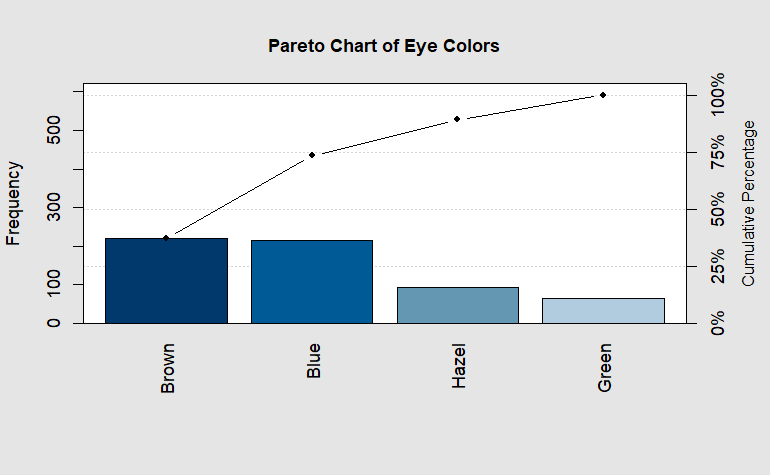

```r
eye_count <- apply(HairEyeColor, c(2), sum) #2 refers to eyes
pareto.chart(eye_count, main = "Pareto Chart of Eye Colors")
```

`Titanic` is stored as a table.

```r
data(Titanic, package="qcc")
Titanic
```

```
, , Age = Child, Survived = No

      Sex
Class  Male Female
  1st     0      0
  2nd     0      0
  3rd    35     17
  Crew    0      0

, , Age = Adult, Survived = No

      Sex
Class  Male Female
  1st   118      4
  2nd   154     13
  3rd   387     89
  Crew  670      3

, , Age = Child, Survived = Yes

      Sex
Class  Male Female
  1st     5      1
  2nd    11     13
  3rd    13     14
  Crew    0      0

, , Age = Adult, Survived = Yes

      Sex
Class  Male Female
  1st    57    140
  2nd    14     80
  3rd    75     76
  Crew  192     20
```

```
Pareto chart analysis for class_count
        Frequency  Cum.Freq. Percentage Cum.Percent.
  Crew  885.00000  885.00000   40.20900     40.20900
  3rd   706.00000 1591.00000   32.07633     72.28532
  1st   325.00000 1916.00000   14.76602     87.05134
  2nd   285.00000 2201.00000   12.94866    100.00000
```

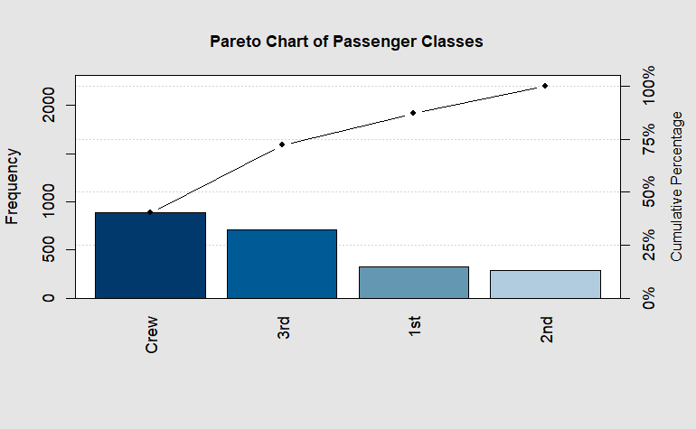

```r
class_count <- apply(Titanic, c(1), sum) #1 refers to Class
pareto.chart(class_count, main = "Pareto Chart of Passenger Classes")
```

`defects` is stored as an ordered vector of counts.

```
Pareto chart analysis for defects
                 Frequency  Cum.Freq. Percentage Cum.Percent.
  Scratches      40.000000  40.000000  42.105263    42.105263
  Dents          25.000000  65.000000  26.315789    68.421053
  Misalignment   15.000000  80.000000  15.789474    84.210526
  Discoloration  10.000000  90.000000  10.526316    94.736842
  Other           5.000000  95.000000   5.263158   100.000000
```

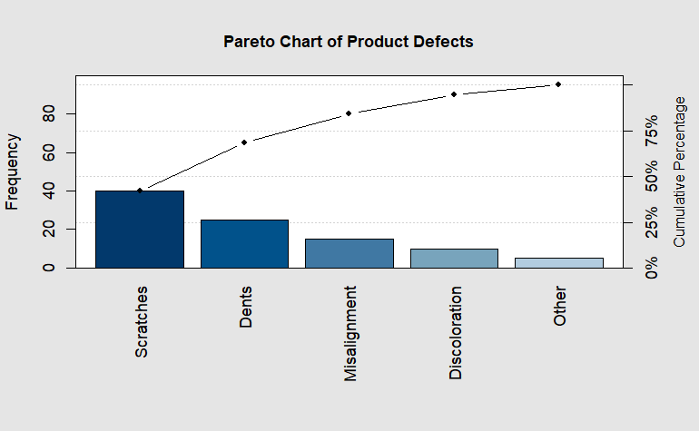

```r
defects <- c("Scratches" = 40, "Dents" = 25, "Misalignment" = 15, "Discoloration" = 10, "Other" = 5)
pareto.chart(defects, main = "Pareto Chart of Product Defects")
```

These plots are not structured with `ggplot`. But they work.

# The `mbadtools` Method

We use the data management and plotting functions in my package. All begin with `pareto_`.

First step is to create a summarized dataset.

```r
A = mtcars %>% mutate(cyl= as.character(cyl))
A1 = A %>% group_by(cyl) %>% summarize(c_count=n())
A1
```

| cyl | c_count |
| --- | --- |
| 4 | 11 |
| 6 | 7 |
| 8 | 14 |

Now apply `pareto_arrange_data()` function to A1.

```r
A2 = A1 %>% pareto_arrange_data(c_count)
A2
```

| cyl | c_count | Cumulative | Percentage |
| --- | --- | --- | --- |
| 8 | 14 | 14 | 43.750 |
| 4 | 11 | 25 | 78.125 |
| 6 | 7 | 32 | 100.000 |

Now the basic plot.

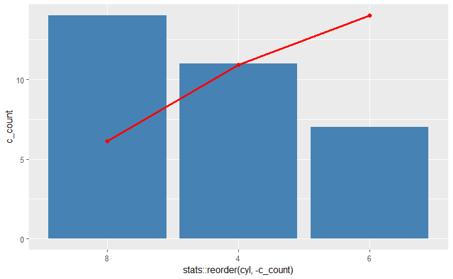

```r
PPlot = A2 %>% pareto_plot(cyl, c_count)
PPlot
```

Add second axis label:

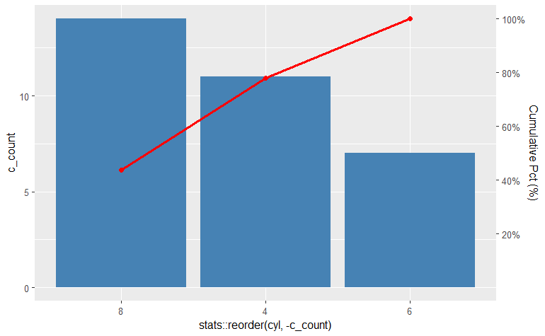

```r
mc = max(A2$c_count)
PPlot +
  pareto_sec_axis(mc)
```

Add percent labels on the cumulative percent line. You can control them with `nudge_y` and `size`.

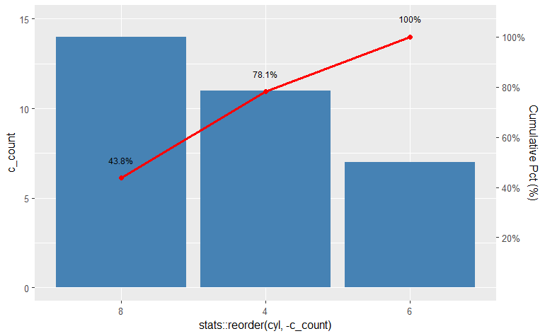

```r
mc = max(A2$c_count)
PPlot +
  pareto_sec_axis(mc) +
  pareto_pct_labels(mc, nudge_y=1, size=3)
```

Add a percent cutoff line and plot labeling:

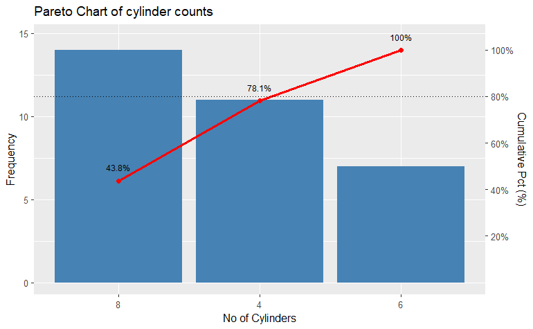

```r
mc = max(A2$c_count)
PPlot +
    pareto_sec_axis(mc) +
    pareto_pct_labels(mc, nudge_y=.8, size=3) +
    pareto_cutoff_line(mc) +
    labs(title = "Pareto Chart of cylinder counts",
       x = "No of Cylinders",
       y = "Frequency")
```

This is what we want our Pareto chart to look like, with all the attachments. You may not want both the right hand axis and the cutoff line.

# Examples from ChatGPT

I had ChatGPT find some data examples that would work for Pareto plots.

## US Cities

```r
data("us.cities", package="maps")  # U.S. cities dataset
# us.cities
U = us.cities %>% group_by(country.etc) %>%
  summarize(cpop = sum(pop))
U1 = U %>% pareto_arrange_data(cpop)
U1
```

| country.etc | cpop | Cumulative | Percentage |
| --- | --- | --- | --- |
| CA | 26729306 | 26729306 | 21.18418 |
| TX | 12880454 | 39609760 | 31.39251 |
| NY | 10030580 | 49640340 | 39.34220 |
| FL | 7400030 | 57040370 | 45.20705 |
| IL | 5715212 | 62755582 | 49.73662 |
| AZ | 4394417 | 67149999 | 53.21939 |
| MA | 3646754 | 70796753 | 56.10961 |
| MI | 3571221 | 74367974 | 58.93996 |
| OH | 3352367 | 77720341 | 61.59686 |
| NJ | 2772034 | 80492375 | 63.79382 |

[output cut: 41 more lines]

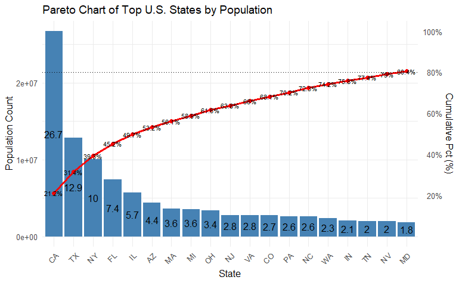

```r
U1 %>% head(19) %>%
  pareto_plot(country.etc, cpop) +
  labs(title = "Pareto Chart of Top U.S. States by Population",
       x = "State",
       y = "Population Count") +
  pareto_pct_labels(max(U1$cpop), size=2.7) +
  pareto_sec_axis(max(U1$cpop)) +
  pareto_cutoff_line(max(U1$cpop)) +
  geom_text(aes(x=country.etc, y=cpop/2,
                label = round(cpop/1e6,1))
            ) +
  theme_minimal() +
  theme(axis.text.x = element_text(angle=45, hjust=1))
```

19 states make up 80% of the US population.

## NYC Flights

```r
library(nycflights13)
# Group by delay reason and count occurrences
delay_data <- flights %>%
  dplyr::filter(dep_delay > 0) %>%
  mutate(delay_category = case_when(
    dep_delay < 15 ~ "Short Delay",
    dep_delay < 60 ~ "Medium Delay",
    TRUE ~ "Long Delay"
  )) %>%
  group_by(delay_category) %>%
  summarise(count = n())
delay_data
```

| delay_category | count |
| --- | --- |
| Long Delay | 27059 |
| Medium Delay | 45855 |
| Short Delay | 55518 |

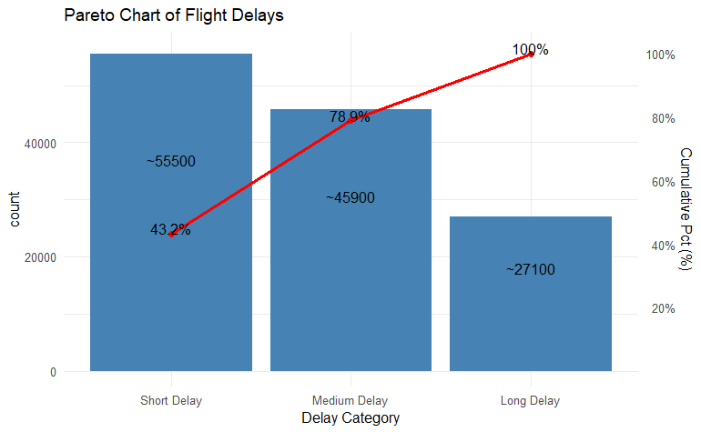

```r
D1 = delay_data %>% pareto_arrange_data(count)
mx=max(D1$count)
D1 %>% pareto_plot(delay_category, count) +
  pareto_pct_labels(mx, nudge_y=1000) +
  pareto_sec_axis(mx) +
  geom_text(aes(x=delay_category,
                y=count/1.5,
                label = paste0("~",round(count,-2)))
            ) +
  labs(title = "Pareto Chart of Flight Delays",
       x = "Delay Category") +
  theme_minimal()
```

## Logistics

Container flows for countries from 2010 thru 2019.

```r
library(readxl)
ContainerFlows <- read_excel(
  "../inst/API_IS.SHP.GOOD.TU_DS2_en_excel_v2_1657.xls",
  skip = 3)
ContainerFlows %>% skim()
```

```
── Data Summary ────────────────────────
                           Values
Name                       Piped data
Number of rows             266
Number of columns          68
_______________________
Column type frequency:
  character                4
  logical                  41
  numeric                  23
________________________
Group variables            None
```

|  | skim_variable | n_missing | complete_rate | min | max | empty | n_unique | whitespace |
| --- | --- | --- | --- | --- | --- | --- | --- | --- |
| 1 | Country Name | 0 | 1 | 4 | 52 | 0 | 266 | 0 |
| 2 | Country Code | 0 | 1 | 3 | 3 | 0 | 266 | 0 |
| 3 | Indicator Name | 0 | 1 | 54 | 54 | 0 | 1 | 0 |
| 4 | Indicator Code | 0 | 1 | 14 | 14 | 0 | 1 | 0 |

|  | skim_variable | n_missing | complete_rate | mean | count |
| --- | --- | --- | --- | --- | --- |
| 1 | 1960 | 266 | 0 | NaN | : |
| 2 | 1961 | 266 | 0 | NaN | : |
| 3 | 1962 | 266 | 0 | NaN | : |
| 4 | 1963 | 266 | 0 | NaN | : |
| 5 | 1964 | 266 | 0 | NaN | : |
| 6 | 1965 | 266 | 0 | NaN | : |
| 7 | 1966 | 266 | 0 | NaN | : |
| 8 | 1967 | 266 | 0 | NaN | : |
| 9 | 1968 | 266 | 0 | NaN | : |
| 10 | 1969 | 266 | 0 | NaN | : |

[output cut: 31 more lines]

|  | skim_variable | n_missing | complete_rate | mean | sd | p0 | p25 | p50 | p75 | p100 | hist |
| --- | --- | --- | --- | --- | --- | --- | --- | --- | --- | --- | --- |
| 1 | 2000 | 184 | 0.3082707 | 21158595 | 39452632 | 14153.0000 | 895181.5 | 2979745.0 | 16790013 | 224774536 | ▇▁▁▁▁ |
| 2 | 2001 | 178 | 0.3308271 | 20797224 | 40234542 | 18218.0000 | 730992.8 | 2570401.0 | 14148184 | 235075458 | ▇▁▁▁▁ |
| 3 | 2002 | 185 | 0.3045113 | 25782005 | 47334631 | 23853.0000 | 1086720.0 | 3570260.0 | 16986010 | 263456511 | ▇▁▁▁▁ |
| 4 | 2003 | 178 | 0.3308271 | 26792950 | 51491789 | 42326.0000 | 1017592.0 | 3517217.0 | 17232347 | 296996130 | ▇▁▁▁▁ |
| 5 | 2004 | 177 | 0.3345865 | 30570955 | 58830520 | 76550.0000 | 1213919.0 | 3926147.0 | 19745369 | 338433750 | ▇▁▁▁▁ |
| 6 | 2005 | 181 | 0.3195489 | 34135017 | 64818646 | 94223.0000 | 1490372.0 | 4982092.0 | 23192200 | 376268146 | ▇▁▁▁▁ |
| 7 | 2006 | 181 | 0.3195489 | 38467733 | 72558341 | 112906.0000 | 1749565.0 | 5372832.0 | 24805717 | 416751971 | ▇▁▁▁▁ |
| 8 | 2007 | 123 | 0.5375940 | 27839277 | 69333768 | 649.0000 | 346076.0 | 1695258.0 | 12243252 | 489818309 | ▇▁▁▁▁ |
| 9 | 2008 | 113 | 0.5751880 | 27864960 | 71674827 | 9317.0000 | 321000.0 | 1325194.0 | 12626588 | 516152333 | ▇▁▁▁▁ |
| 10 | 2009 | 113 | 0.5751880 | 25724765 | 65947981 | 7045.0000 | 290098.6 | 1240251.5 | 10066374 | 472175125 | ▇▁▁▁▁ |

[output cut: 13 more lines]

Select the years with most nations’ data complete.

```r
CF = ContainerFlows %>% select(`Country Name`, `Country Code`,
                               `2010`, `2011`, `2012`, `2013`, `2014`,
                               `2015`, `2016`, `2017`, `2018`, `2019`)
CF %>% skim
```

```
── Data Summary ────────────────────────
                           Values
Name                       Piped data
Number of rows             266
Number of columns          12
_______________________
Column type frequency:
  character                2
  numeric                  10
________________________
Group variables            None
```

|  | skim_variable | n_missing | complete_rate | min | max | empty | n_unique | whitespace |
| --- | --- | --- | --- | --- | --- | --- | --- | --- |
| 1 | Country Name | 0 | 1 | 4 | 52 | 0 | 266 | 0 |
| 2 | Country Code | 0 | 1 | 3 | 3 | 0 | 266 | 0 |

|  | skim_variable | n_missing | complete_rate | mean | sd | p0 | p25 | p50 | p75 | p100 | hist |
| --- | --- | --- | --- | --- | --- | --- | --- | --- | --- | --- | --- |
| 1 | 2010 | 69 | 0.7406015 | 23703888 | 69690895 | 1718.7490 | 99048.0 | 717700.0 | 6457959 | 549045861 | ▇▁▁▁▁ |
| 2 | 2011 | 61 | 0.7706767 | 25142568 | 74800579 | 2596.9970 | 101401.0 | 810248.0 | 7560789 | 595673258 | ▇▁▁▁▁ |
| 3 | 2012 | 59 | 0.7781955 | 26256555 | 78759646 | 1419.9870 | 110256.0 | 880104.0 | 7928728 | 625012231 | ▇▁▁▁▁ |
| 4 | 2013 | 58 | 0.7819549 | 27141817 | 81779706 | 472.6140 | 111030.2 | 883404.5 | 8310767 | 645939512 | ▇▁▁▁▁ |
| 5 | 2014 | 58 | 0.7819549 | 28521611 | 85992061 | 472.6140 | 129549.0 | 889967.9 | 9094823 | 676980346 | ▇▁▁▁▁ |
| 6 | 2015 | 57 | 0.7857143 | 28970669 | 87721495 | 735.0142 | 120491.6 | 860278.0 | 8883542 | 686811737 | ▇▁▁▁▁ |
| 7 | 2016 | 59 | 0.7781955 | 30010314 | 90559800 | 735.0142 | 125521.8 | 942463.0 | 8861115 | 702873287 | ▇▁▁▁▁ |
| 8 | 2017 | 59 | 0.7781955 | 32129651 | 96897635 | 735.0142 | 125656.4 | 958488.0 | 9970112 | 749647169 | ▇▁▁▁▁ |
| 9 | 2018 | 59 | 0.7781955 | 33800996 | 101824442 | 735.0142 | 139317.5 | 1056785.0 | 10343393 | 786889621 | ▇▁▁▁▁ |
| 10 | 2019 | 62 | 0.7669173 | 35292255 | 105526779 | 818.0000 | 145060.8 | 1211120.5 | 10725836 | 806572711 | ▇▁▁▁▁ |

Pivot longer.

```r
CF1 = CF %>% pivot_longer(cols=3:12, names_to = "Year",
                          values_to = "Flow")
CF1 %>% glimpse
```

```
Rows: 2,660
Columns: 4
$ `Country Name` <chr> "Aruba", "Aruba", "Aruba", "Aruba", "Aruba", "Aruba", "A…
$ `Country Code` <chr> "ABW", "ABW", "ABW", "ABW", "ABW", "ABW", "ABW", "ABW", …
$ Year           <chr> "2010", "2011", "2012", "2013", "2014", "2015", "2016", …
$ Flow           <dbl> 49558, NA, NA, 30988, 29628, 35342, 31323, 31689, 58500,…
```

Make Year nueric and rename `Country Code` and `Country Name` columns.

```r
CF2 = CF1 %>% mutate(Year = as.numeric(Year)) %>%
  rename(Country=`Country Code`, CName=`Country Name`)
CF2 %>% glimpse
```

```
Rows: 2,660
Columns: 4
$ CName   <chr> "Aruba", "Aruba", "Aruba", "Aruba", "Aruba", "Aruba", "Aruba", …
$ Country <chr> "ABW", "ABW", "ABW", "ABW", "ABW", "ABW", "ABW", "ABW", "ABW", …
$ Year    <dbl> 2010, 2011, 2012, 2013, 2014, 2015, 2016, 2017, 2018, 2019, 201…
$ Flow    <dbl> 49558, NA, NA, 30988, 29628, 35342, 31323, 31689, 58500, 63870,…
```

```r
CF2 %>% skim
```

```
── Data Summary ────────────────────────
                           Values
Name                       Piped data
Number of rows             2660
Number of columns          4
_______________________
Column type frequency:
  character                2
  numeric                  2
________________________
Group variables            None
```

|  | skim_variable | n_missing | complete_rate | min | max | empty | n_unique | whitespace |
| --- | --- | --- | --- | --- | --- | --- | --- | --- |
| 1 | CName | 0 | 1 | 4 | 52 | 0 | 266 | 0 |
| 2 | Country | 0 | 1 | 3 | 3 | 0 | 266 | 0 |

|  | skim_variable | n_missing | complete_rate | mean | sd | p0 | p25 | p50 | p75 | p100 | hist |
| --- | --- | --- | --- | --- | --- | --- | --- | --- | --- | --- | --- |
| 1 | Year | 0 | 1.0000000 | 2014.5 | 2.872821e+00 | 2010.000 | 2012 | 2014.5 | 2017 | 2019 | ▇▇▇▇▇ |
| 2 | Flow | 601 | 0.7740602 | 29116688.3 | 8.798805e+07 | 472.614 | 119182 | 927379.0 | 8880279 | 806572711 | ▇▁▁▁▁ |

Remove missing data.

```r
CF3 = CF2 %>% na.omit
CF3 %>% skim
```

```
── Data Summary ────────────────────────
                           Values
Name                       Piped data
Number of rows             2059
Number of columns          4
_______________________
Column type frequency:
  character                2
  numeric                  2
________________________
Group variables            None
```

|  | skim_variable | n_missing | complete_rate | min | max | empty | n_unique | whitespace |
| --- | --- | --- | --- | --- | --- | --- | --- | --- |
| 1 | CName | 0 | 1 | 4 | 52 | 0 | 210 | 0 |
| 2 | Country | 0 | 1 | 3 | 3 | 0 | 210 | 0 |

|  | skim_variable | n_missing | complete_rate | mean | sd | p0 | p25 | p50 | p75 | p100 | hist |
| --- | --- | --- | --- | --- | --- | --- | --- | --- | --- | --- | --- |
| 1 | Year | 0 | 1 | 2014.518 | 2.856468e+00 | 2010.000 | 2012 | 2015 | 2017 | 2019 | ▇▇▇▇▇ |
| 2 | Flow | 0 | 1 | 29116688.324 | 8.798805e+07 | 472.614 | 119182 | 927379 | 8880279 | 806572711 | ▇▁▁▁▁ |

Make Pareto data frame: use mean of flow over the 10 years for each country. Change mean to millions of containers.

```r
CF4 = CF3 %>% group_by(Country) %>%
  summarize(cflow = mean(Flow, na.rm=T)/1e6)
CF4 %>% glimpse
```

```
Rows: 210
Columns: 2
$ Country <chr> "ABW", "AFW", "AGO", "ALB", "ARB", "ARE", "ARG", "ASM", "ATG", …
$ cflow   <dbl> 4.136225e-02, 6.623824e+00, 7.389613e-01, 1.059301e-01, 4.91780…
```

```r
CF4
```

| Country | cflow |
| --- | --- |
| ABW | 4.136225e-02 |
| AFW | 6.623824e+00 |
| AGO | 7.389613e-01 |
| ALB | 1.059301e-01 |
| ARB | 4.917802e+01 |
| ARE | 1.875546e+01 |
| ARG | 1.937199e+00 |
| ASM | 6.935600e-02 |
| ATG | 2.151090e-02 |
| AUS | 7.626118e+00 |

[output cut: 200 more lines]

```r
df = dplyr::filter(CF4,
  !(Country %in% c("CEB","CSS","EAP","EAR",
                 "EAS","ECS","EMU","EUU",
                 "FCS","HIC","IBD","IBT",
                 "IDA","IDB","LAC","LCN",
                 "LMC","LMY","LTE","MEA",
                 "MIC","MNA","NAC","OED",
                 "OSS","PRE","PSS","PST",
                 "SSA","SST","TEA","TEC",
                 "TLA","TMN","TSA","TSS",
                 "UMC","WLD","ARB","AFW",
                 "SSF"))
              )

df %>% gt() %>% fmt_number(decimals=3) %>% opt_interactive()
```

| Country | cflow |
| --- | --- |
| ABW | 0.04136225 |
| AGO | 0.7389613 |
| ALB | 0.1059301 |
| ARE | 18.7554633 |
| ARG | 1.9371989 |
| ASM | 0.069356 |
| ATG | 0.0215109 |
| AUS | 7.6261178 |
| AUT | 0.2859 |
| BEL | 10.4025062 |

[output cut: 159 more lines]

Get data ready and make Pareto Plot.

```r
df1 = df %>% pareto_arrange_data(cflow)
df1
```

| Country | cflow | Cumulative | Percentage |
| --- | --- | --- | --- |
| CHN | 1.901308e+02 | 190.1308 | 27.48261 |
| USA | 4.741069e+01 | 237.5414 | 34.33563 |
| SGP | 3.257529e+01 | 270.1167 | 39.04425 |
| KOR | 2.483121e+01 | 294.9479 | 42.63350 |
| SAS | 2.289927e+01 | 317.8472 | 45.94349 |
| MYS | 2.253503e+01 | 340.3822 | 49.20084 |
| JPN | 2.171857e+01 | 362.1008 | 52.34017 |
| HKG | 2.142720e+01 | 383.5280 | 55.43738 |
| ARE | 1.875546e+01 | 402.2835 | 58.14840 |
| DEU | 1.501744e+01 | 417.3009 | 60.31911 |

[output cut: 159 more lines]

```r
mc = max(df1$cflow)
```

Pick a number of countries for about 80% and make Pareto Plot.

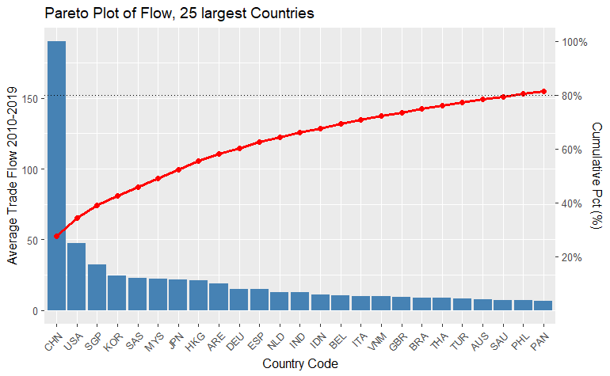

```r
q=25
C = df1 %>% head(q) %>%
  pareto_plot(Country, cflow) +
  labs(title=paste0("Pareto Plot of Flow, ",q," largest Countries"),
       x="Country Code",
       y="Average Trade Flow 2010-2019") +
  theme(axis.text.x = element_text(angle=45, hjust=1)) +
  # pareto_pct_labels(mc) +
  pareto_cutoff_line(mc) +
  pareto_sec_axis(mc)
C
```

We don’t know country codes, so extract the names and make a dataframe with `Country` and `CName`.

```r
a = df$Country %>% enframe(value="Country")

b = data.frame(cn = CF3 %>% distinct(CName),
               Country = CF3 %>% distinct(Country)
               )
c = left_join(a, b, by="Country")
w = c %>% select(-name)
ww = w %>% dplyr::filter(Country %in% (df1 %>% head(q) %>% pull(Country)) )
```

Add the table to the plot display. Note that we do not have to make the table of countries a `gt` table; `wrap_table` does that for us. We may have to change the height and width of the plot, and we specify a design to make the Pareto plot 75% of the plot width.

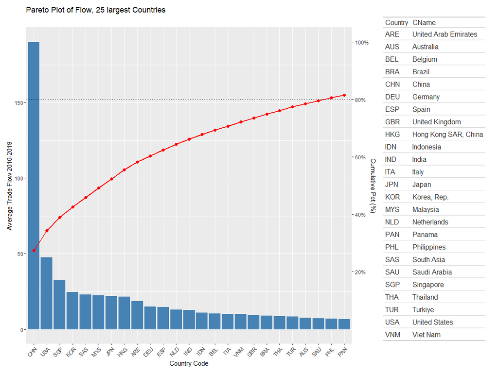

```r
list(C, W=wrap_table(ww)) %>% wrap_plots(design = "CCCW")
```

# Example for package

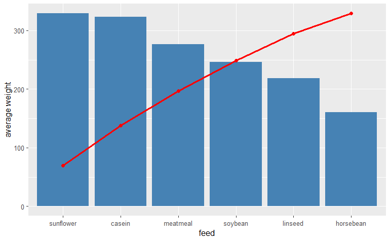

```r
data(chickwts, package="datasets")
chickwts %>% group_by(feed) %>%
  summarize(avwt = mean(weight)) %>%
      pareto_arrange_data(avwt) %>%
        pareto_plot(feed, avwt) +
        labs(x="feed",
             y="average weight")
```

# Conclusion

Tests show the Pareto plots are working.